# Homework 1: Data Visualization & Google Trends on Three Different Measures from Turkey

In this homework, time series analysis of interest rate levels, unemployment rate levels, and percentage change of cost of living indices for wage earners in İstanbul will be performed over the years using monthly data. The aim is to analyze specific characteristics of these chosen datasets and show that there is a pattern both with regard to time and each other. In addition, GoogleTrends data for search keywords “iskur” and “zam” are included to deepen the analysis.

## 1) Data Gathering and Manipulations

### a. Monthly Interest Rates of Turkey

This measure’s data set consists of monthly reported values of interest rates in Turkey. The data is taken between 2002 and 2021.After the necessary manipulations and some cleaning, head of this data frame is as follows:

```
##         Date InterestRates
## 1 2002-01-01       74.8750
## 2 2002-02-01       71.6350
## 3 2002-03-01       65.5560
## 4 2002-04-01       60.7325
## 5 2002-05-01       53.1160
## 6 2002-06-01       52.7525
```

Dummy day information to the date is added since it is easier to plot and visualize the data with the full date.

### b. Monthly Unemployment Rates of Turkey

This second measure’s data set consists of monthly reported values of unemployment rates as percentage in Turkey. The data is taken between 2014 and 2021 as it was only available for this period .After the necessary manipulations and some cleaning, head of this data frame is as follows:

```
##         Date UnemploymentRates
## 1 2014-01-01              10.5
## 2 2014-02-01              10.5
## 3 2014-03-01               9.4
## 4 2014-04-01               8.8
## 5 2014-05-01               8.4
## 6 2014-06-01               9.0
```

### c. Monthly Percentage Change of Cost of Living Indices for Wage Earners-Istanbul

This last dataset covers the information about general expenses of a typical wage earner in İstanbul. Since first two data are in the form of rates, this measure is chosen as percentage change instead of gross levels. In substance, this data mimics CPI for İstanbul.Performing the same manipulations as above:

```
##         Date CostOfLiving
## 1 2002-01-01   2.21831973
## 2 2002-02-01   1.11623835
## 3 2002-03-01   2.76240128
## 4 2002-04-01   5.99938055
## 5 2002-05-01   2.54915780
## 6 2002-06-01   0.01389595
```

### d. Google Trends Search for “iskur” & “zam”

As Google Trends search keywords “iskur” and “zam” are selected. “zam” means “increase in prices/wages” in Turkish. It is a widely used word in internet searches when people are expecting a raise in minimum wage. “iskur” is the legal regulation regarding public employment services in Turkey and people wanting to be employed most probably visits the iskur’s website. The data provided by Google Trends for this keyword was also monthly.

```
##         Date iskur zam
## 1 2004-01-01     4   2
## 2 2004-02-01     3   1
## 3 2004-03-01     2   3
## 4 2004-04-01     5   3
## 5 2004-05-01     4   2
## 6 2004-06-01     3   1
```

## 2) Data Visualizations

### a. Data from EVDS

These datasets are merged into one dataframe containing only the years that do not have NA values for any column (2014-2021).

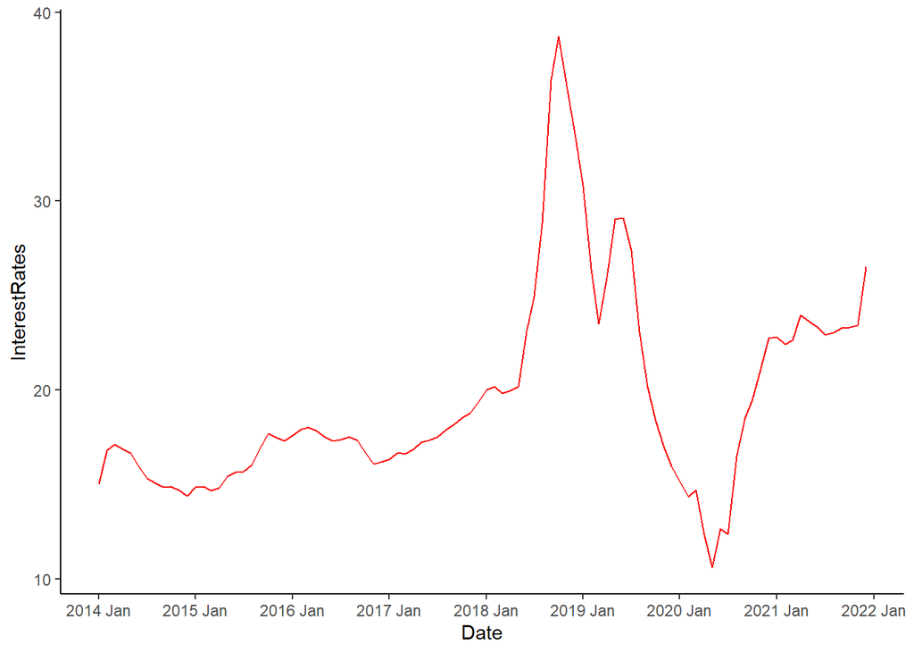

```r
EVDS1 <- merge(InterestEVDS,UnemploymentEVDS,by='Date')
EVDS <- merge(EVDS1,COLEVDS,by='Date')

ggplot(EVDS, aes(Date,InterestRates)) +
  geom_line(na.rm=TRUE,colour='red')+theme_classic()+scale_x_date(date_breaks = "1 year", date_labels = "%Y %b", date_minor_breaks = "1 month")
```

If we look at the plot of Interest Rates over time, we can see fluctuations over time and general trend to increase except for the COVID period in March 2020. We are also able to observe seemingly unusual peak in close to the beginning of 2019. This is due to volatility in Turkey’s economy and politics.

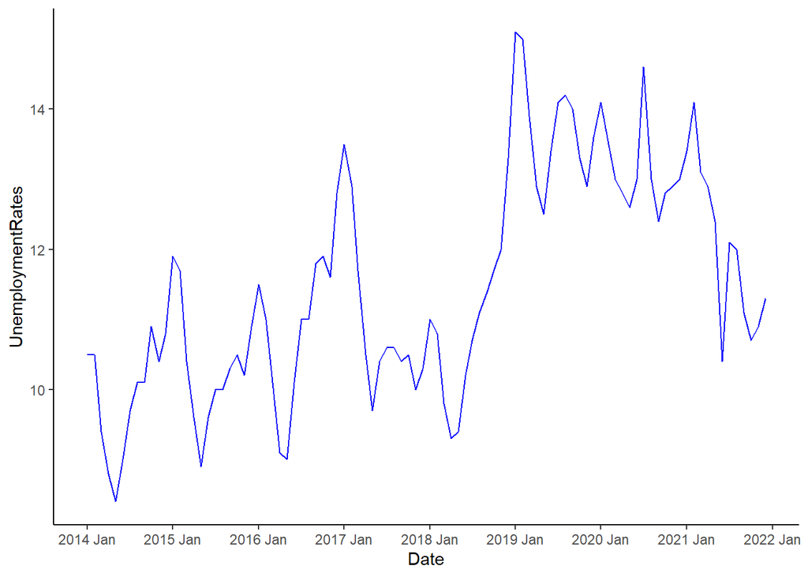

```r
ggplot(EVDS, aes(Date,UnemploymentRates)) +
  geom_line(na.rm=TRUE,colour='blue')+theme_classic()+scale_x_date(date_breaks = "1 year", date_labels = "%Y %b", date_minor_breaks = "1 month")
```

Even though, fluctuations seems more than interest rates this is due to scale differences and we see again a general increase in unemployment rates. The effect of COVID is not as obvious as it was in the previous case. Seasonal workers’ effect is also observed.

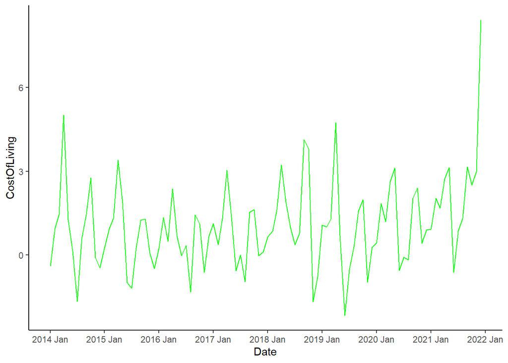

```r
ggplot(EVDS, aes(Date,CostOfLiving)) +
  geom_line(na.rm=TRUE,colour='green')+scale_x_date(date_breaks = "1 year", date_labels = "%Y %b", date_minor_breaks = "1 month")+theme_classic()
```

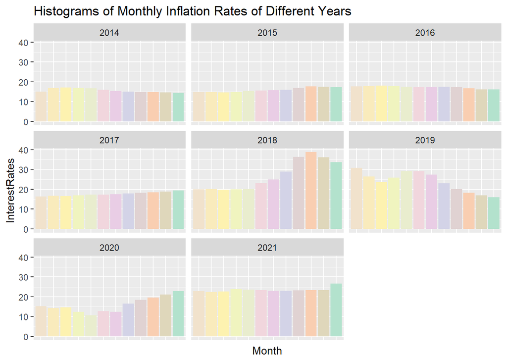

```r
ggplot(EVDS,aes(x=factor(month(Date)),y=InterestRates))+geom_bar(stat="identity",aes(fill=month(Date)))+facet_wrap(~year(Date))+
  theme(legend.position = "none",
        axis.ticks.x = element_blank(),
        axis.text.x = element_blank())+
  labs(x="Month",title="Histograms of Monthly Inflation Rates of Different Years")+scale_fill_distiller(palette="Pastel2")
```

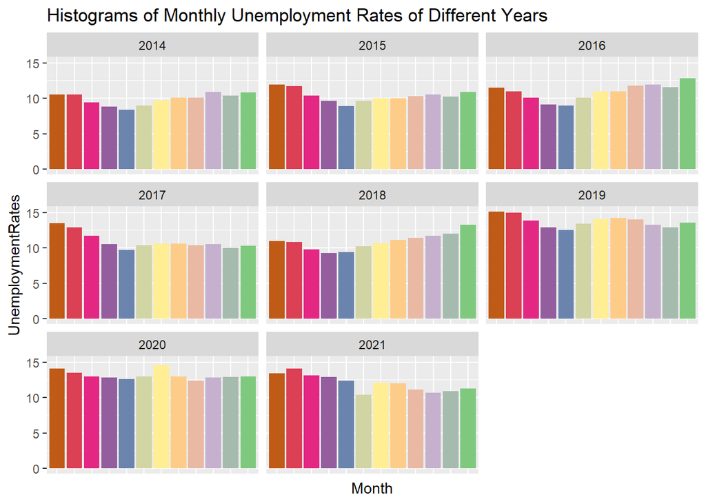

```r
ggplot(EVDS,aes(x=factor(month(Date)),y=UnemploymentRates))+geom_bar(stat="identity",aes(fill=month(Date)))+facet_wrap(~year(Date))+
  theme(legend.position = "none",
        axis.ticks.x = element_blank(),
       axis.text.x = element_blank())+
  labs(x="Month",title="Histograms of Monthly Unemployment Rates of Different Years")+scale_fill_distiller(palette="Accent")
```

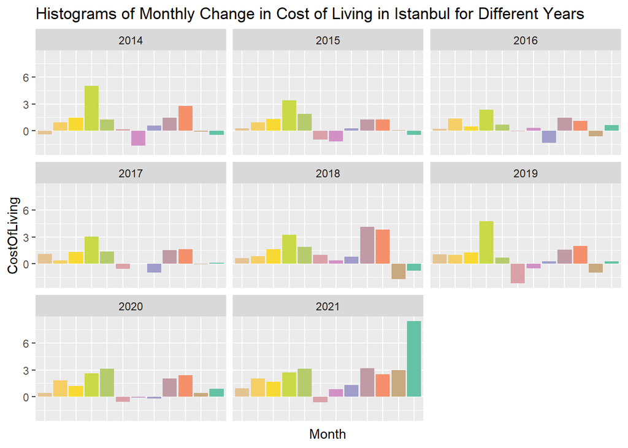

```r
ggplot(EVDS,aes(x=factor(month(Date)),y=CostOfLiving))+geom_bar(stat="identity",aes(fill=month(Date)))+facet_wrap(~year(Date))+
  theme(legend.position = "none",
        axis.ticks.x = element_blank(),
        axis.text.x = element_blank())+
  labs(x="Month",title="Histograms of Monthly Change in Cost of Living in İstanbul for Different Years")+scale_fill_distiller(palette="Set2")
```

### b. Data from Google Trends

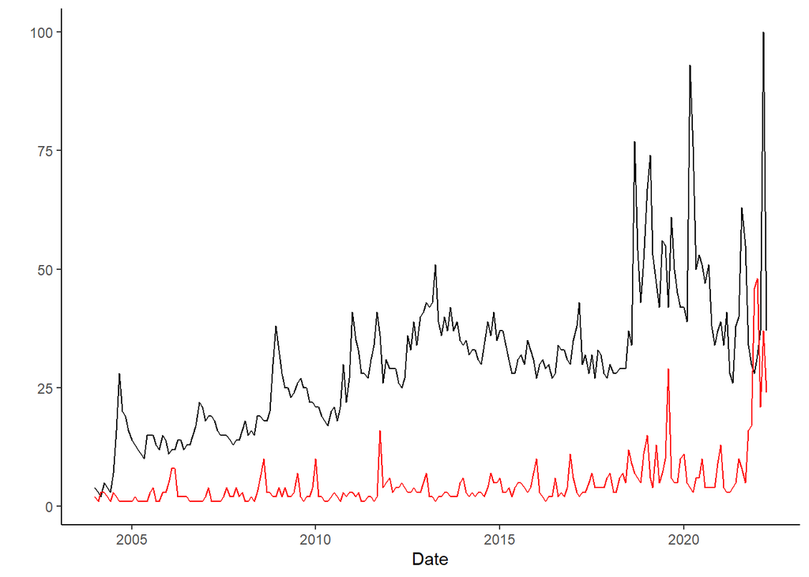

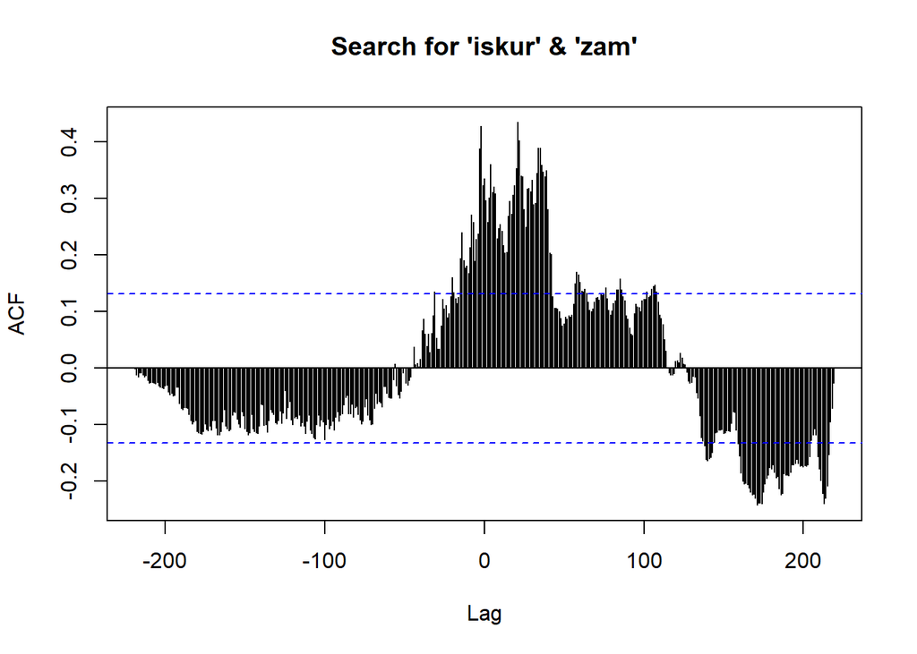

It is shown that there is again a general increase in the search for both “iskur” and “zam” with some fluctuations. Also,there may be a relation between the search for “iskur” and “zam” however there seems to be lag that makes it hard to see the correlation clearly. To get rid of the effects of this, the lag that gives the biggest correlation is found and the plot is redone considering this lag:

```
##           cor lag
## 237 0.4345196  21
```

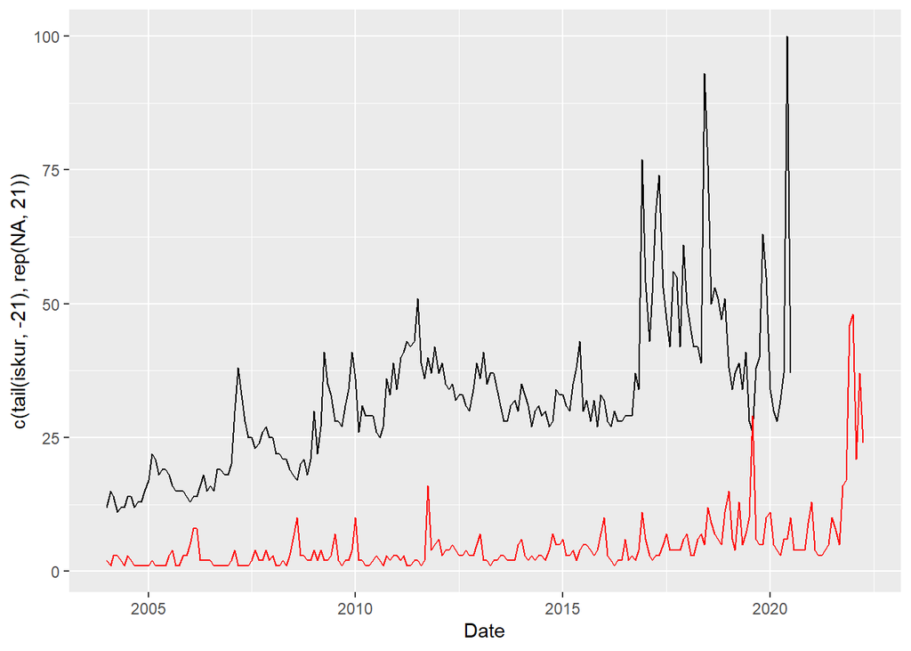

### c. Data from both Google Trends and EVDS

Lastly, I wanted to plot unemployment rate versus “iskur” search in time as strong correlation between them is expected.

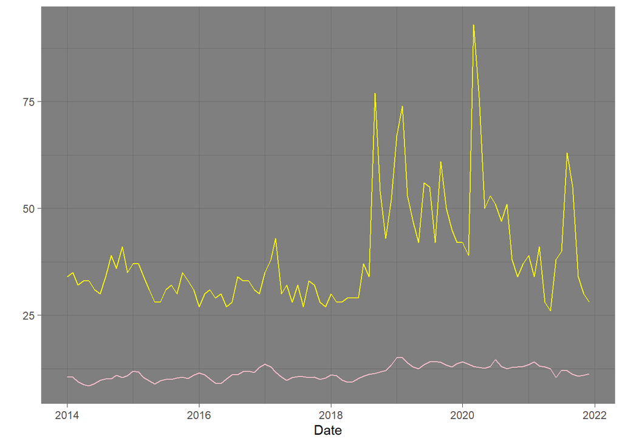

```
## [1] 0.5932848
```

High correlation around 0.59 is observed as expected.

## 3) Correlations and Comparisons

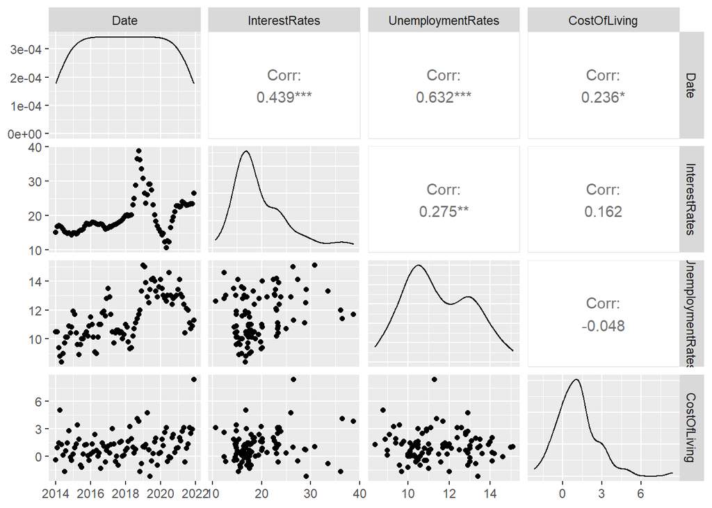

```r
ggpairs(EVDS)
```

  However, percentage change in the cost of living indices for İstanbul does not seem to be correlated with the other two.

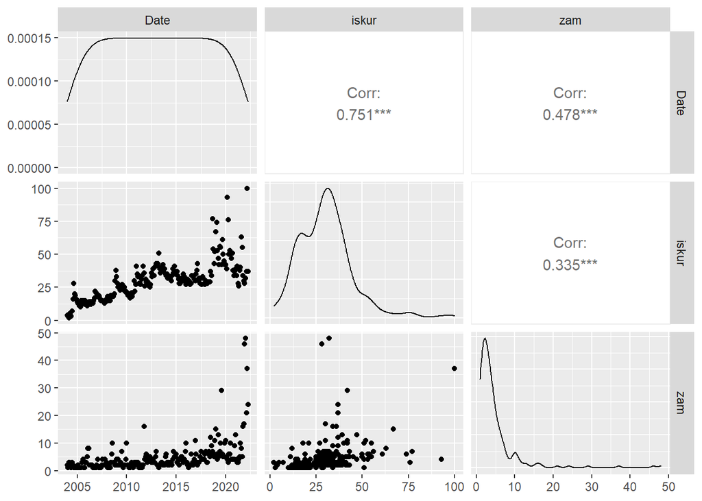

```r
ggpairs(trends)
```

## 4) Conclusion

For R file click [here.](https://github.com/BU-IE-360/spring22-elifatilgan/blob/gh-pages/files/hw1.R)